# Hippocampal proteome: ACT vs Sham

Hippocampus proteome (McElroy et al. 2020)

2026-11-14

8

samples

5,200

proteins tested

29

up in ACT

9

down in ACT

20 / 38

DE calls robust without imputation

104 / 12

GSEA terms GO / KEGG (padj < 0.05)

## Study design

Hippocampus of 4-month-old female C57BL/6 mice, about four weeks after ACT chemotherapy (doxorubicin + cyclophosphamide, then paclitaxel) or sham treatment. Label-free LC-MS/MS quantified with MaxQuant (iBAQ). Data from Table S1 of the supplementary file (`ijms-730741`) of McElroy et al. (2020), [*Int. J. Mol. Sci.* 21(5):1867](https://doi.org/10.3390/ijms21051867), PMID 32182883.

- **Sham**: 4 samples.
- **ACT**: 4 samples.

> **Independent re-analysis.** Only the raw iBAQ values are used. The authors' normalized values, statistics and protein tables are not used or compared.

> **Chemotherapy effect only.** The study also has MnBuOE and ACT-MnBuOE groups; they are excluded on purpose.

> **Replicate pair as batch.** Replicates 1–2 and 3–4 differ strongly in depth (missing values) in both groups, so the pair is a blocking factor in the model.

## Pipeline

1. **prepare** (`scripts/prepare.sh`): extracts annotation + raw iBAQ of the Sham and ACT samples from Table S1 into `data/processed.csv`.
2. **limma_analysis** (`scripts/ACT_mcelroy_limma_ijms730741.R`): filtering, normalization, imputation, limma, sensitivity analysis without imputation, QC/DE plots, GSEA (GO, KEGG) and ORA.
3. **report** (`scripts/report.py`): this page.

Shared settings:

- **Filter:** proteins with ≥ 3 valid (non-zero) iBAQ values in at least one group.
- **Normalization:** log2, then median centering per sample.
- **Imputation:** left-censored (MinProb-like) draws from N(mean − 1.8 SD, 0.3 SD) per sample, seed 42.
- **limma:** `~ 0 + group + batch` (batch = replicate pair 1–2 vs 3–4), `eBayes(trend = TRUE)`, contrast ACT − Sham. Positive log2FC = higher in **ACT**.
- **DE call:** `FDR < 0.05` and `|log2FC| > 0.5`; if no protein passes FDR, the unadjusted `P < 0.01` is used instead (same fold-change cutoff).
- **GSEA:** proteins ranked by sign(log2FC) × −log10(P); GO (BP, CC, MF) and KEGG (`mmu`) with clusterProfiler, gene sets 10–500, Benjamini-Hochberg, fixed seed. Positive NES = enriched in ACT.
- **ORA:** GO BP of the up and down sets against the identified proteome (not the whole genome).

## Input data

Input is Table S1 of the supplementary file: one row per MaxQuant protein group, with raw iBAQ intensities per sample. A value of 0 means the protein was not quantified in that sample.

**5,514** protein groups are in the table; **5,200** pass the valid-value filter. Replicates 1–2 have many more missing values than replicates 3–4 in both groups.

**Table 1.** Proteins quantified per sample (iBAQ > 0).

| sample | group | batch (replicate pair) | quantified | missing values |
| --- | --- | --- | --- | --- |
| Sham_1 | Sham | B1 | 4,455 | 1,059 |
| Sham_2 | Sham | B1 | 4,324 | 1,190 |
| Sham_3 | Sham | B2 | 5,306 | 208 |
| Sham_4 | Sham | B2 | 5,238 | 276 |
| ACT_1 | ACT | B1 | 4,547 | 967 |
| ACT_2 | ACT | B1 | 4,939 | 575 |
| ACT_3 | ACT | B2 | 5,299 | 215 |
| ACT_4 | ACT | B2 | 5,194 | 320 |

## Quality control

These plots check the data before testing. After median centering the samples should have similar distributions, and replicates of the same group should be close in the PCA.

### Intensity distributions

```r
## Densities before / after normalization and imputation
long <- function(m, stage) data.frame(m, check.names = FALSE) %>%
  pivot_longer(everything(), names_to = "sample", values_to = "log2_iBAQ") %>%
  mutate(stage = stage)
dens <- bind_rows(long(log_filt, "1 filtered"), long(log_norm, "2 normalized"),
                  long(log_imp, "3 imputed")) %>%
  filter(!is.na(log2_iBAQ)) %>%
  mutate(group = sub("_.*", "", sample))
p_dens <- ggplot(dens, aes(log2_iBAQ, colour = sample, linetype = group)) +
  geom_density() + facet_wrap(~stage, ncol = 1) + theme_bw()
save_plot(p_dens, "density_preprocessing.pdf", height = 8)
```

From `ACT_mcelroy_limma_ijms730741.R`

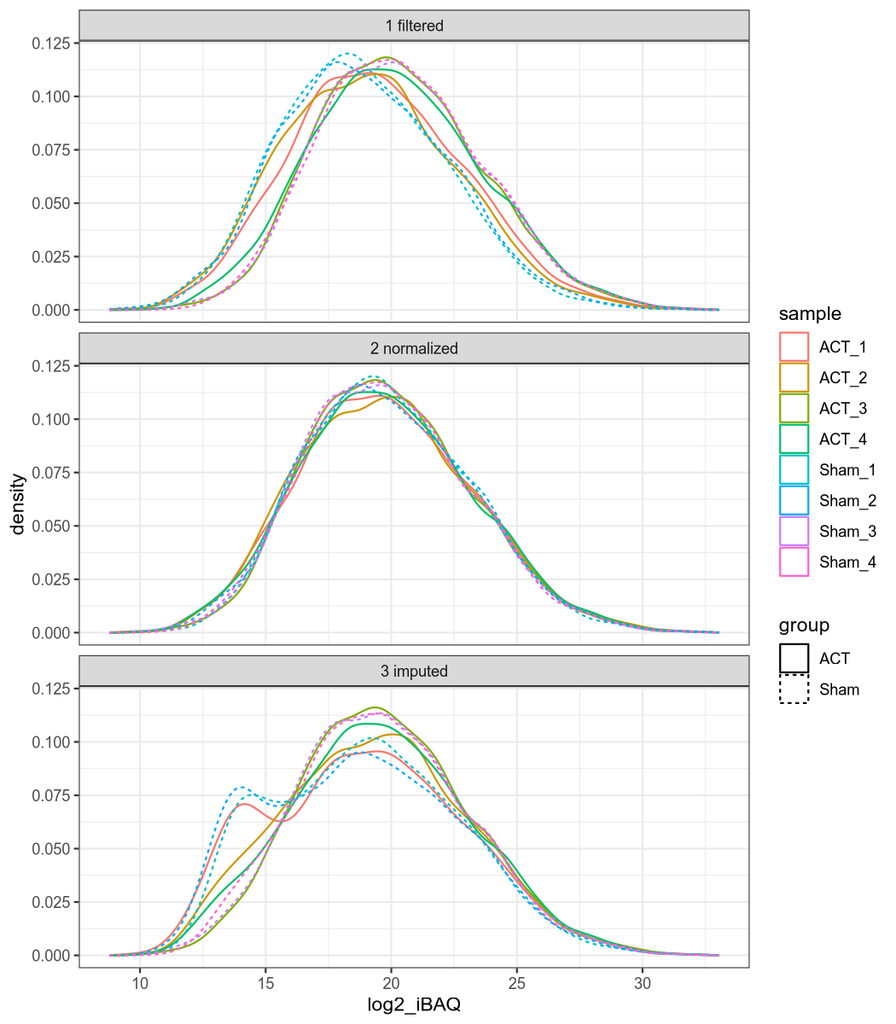

**Figure 1.** Density of log2 iBAQ per sample after filtering, after normalization and after imputation. The imputed values form the low-intensity shoulder.

```r
## Boxplot after normalization (before imputation)
p_box <- long(log_norm, "normalized") %>% filter(!is.na(log2_iBAQ)) %>%
  mutate(group = sub("_.*", "", sample)) %>%
  ggplot(aes(sample, log2_iBAQ, fill = group)) + geom_boxplot(outlier.size = 0.3) +
  scale_fill_manual(values = group_colors) + theme_bw() +
  theme(axis.text.x = element_text(angle = 45, hjust = 1))
save_plot(p_box, "boxplot_normalized.pdf")
```

From `ACT_mcelroy_limma_ijms730741.R`

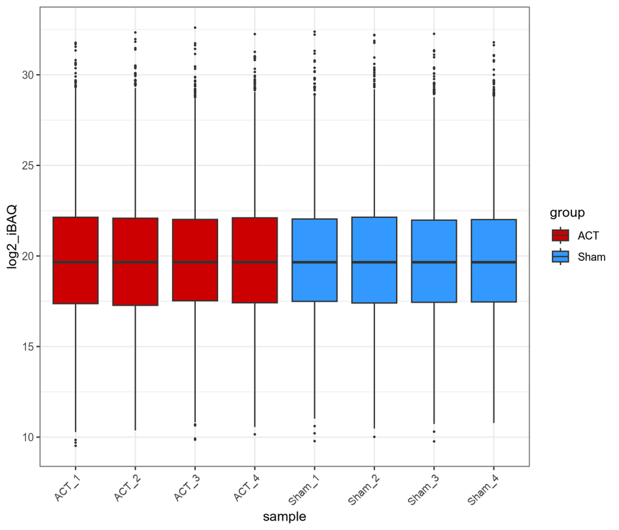

**Figure 2.** Normalized log2 iBAQ per sample (before imputation), colored by group.

### Sample similarity

Replicates 1–2 and 3–4 form two batches (replicate pairs) with very different depth, each with 2 Sham and 2 ACT samples. Without correction the batch is the largest source of variation in the PCA. The limma model estimates it as a term (`~ 0 + group + batch`); for the plots below the batch is removed with `limma::removeBatchEffect` (group effect protected), so they show the variation left after the batch.

Variance explained after batch correction: PC1=27.4%, PC2=22.4%, PC3=20.7%, PC4=12%.

```r
## PCA of samples (imputed, batch-corrected matrix)
pca <- prcomp(t(log_bc), scale. = FALSE)
var_expl <- round(100 * pca$sdev^2 / sum(pca$sdev^2), 1)
pca_df <- cbind(metadata, pca$x[, 1:3])
p_pca <- ggplot(pca_df, aes(PC1, PC2, colour = group, shape = batch, label = sample)) +
  geom_point(size = 4) + geom_text_repel(show.legend = FALSE) +
  scale_colour_manual(values = group_colors) +
  labs(x = paste0("PC1 (", var_expl[1], "%)"), y = paste0("PC2 (", var_expl[2], "%)"),
       title = "PCA, batch-corrected (removeBatchEffect)") +
  theme_bw()
save_plot(p_pca, "pca.pdf")
```

From `ACT_mcelroy_limma_ijms730741.R`

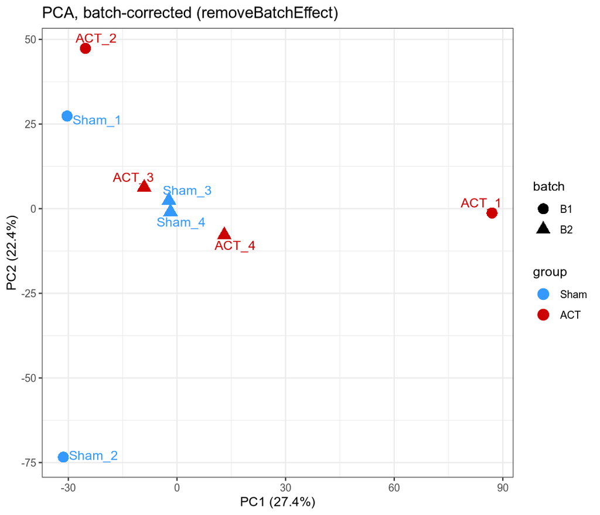

**Figure 3.** PCA of the imputed log2 intensities after removing the batch. Color = group, shape = batch (replicate pair).

## Differential abundance

5,200 proteins were tested. **38 proteins** pass `unadjusted P < 0.01` and `|log2FC| > 0.5`: **29 up** and **9 down** in ACT.

No protein passes `FDR < 0.05` (0 without the fold-change cutoff), so the unadjusted `P < 0.01` is used. These calls are **exploratory**: with ~5,200 tests, about 52 proteins are expected below `P < 0.01` by chance alone.

```r
# Volcano plot: Up = red, Down = blue, NS = gray (same scheme as bulk-rna-seq)
keyvals <- ifelse(tt$status == "Up", "#CC0000", ifelse(tt$status == "Down", "#3399FF", "gray"))
names(keyvals) <- ifelse(keyvals == "#CC0000", "Up", ifelse(keyvals == "#3399FF", "Down", "NS"))
sig_label <- if (sig_col == "adj.P.Val") "FDR" else "P"

p_volc <- EnhancedVolcano(tt,
                          lab = tt$SYMBOL,
                          x = "logFC",
                          y = sig_col,
                          xlab = bquote(~Log[2] ~ "fold change"),
                          ylab = bquote(~-Log[10] ~ .(sig_label)),
                          title = cfg$title,
                          subtitle = "ACT vs Sham",
                          caption = paste("Total proteins:", nrow(tt)),
                          pCutoff = sig_cutoff,
                          FCcutoff = fc_cutoff,
                          pointSize = 1.0,
                          labSize = 3,
                          colCustom = keyvals,
                          colAlpha = 0.5,
                          legendLabSize = 7,
                          legendIconSize = 7,
                          drawConnectors = TRUE,
                          widthConnectors = 0.3,
                          max.overlaps = 15)
save_plot(p_volc, "volcano.pdf", width = 8, height = 7)
```

From `ACT_mcelroy_limma_ijms730741.R`

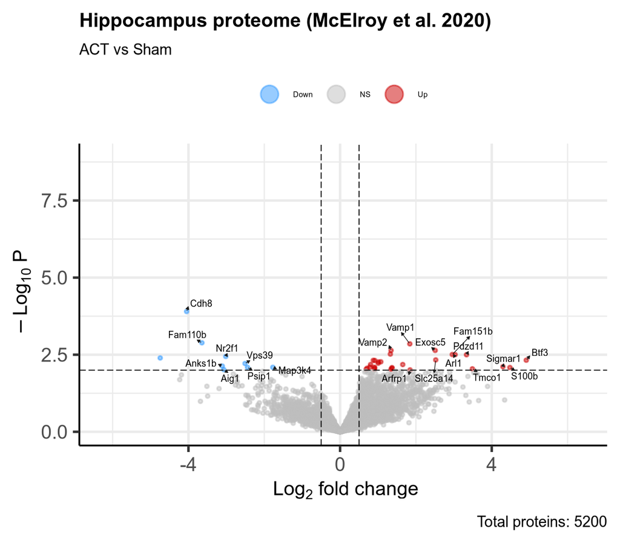

**Figure 4.** Volcano plot: log2 fold change vs unadjusted P. Red = up in ACT, blue = down, gray = not significant.

```r
## MD plot (logFC vs mean log intensity)
save_base("md_plot.pdf", width = 6, height = 5, {
  plotMD(fit2, coef = 1, status = tt$status[match(rownames(fit2), tt$Protein)],
         main = "ACT vs Sham", values = c("Up", "Down"), col = c("#CC0000", "#3399FF"))
  abline(h = 0, col = "grey")
})
```

From `ACT_mcelroy_limma_ijms730741.R`

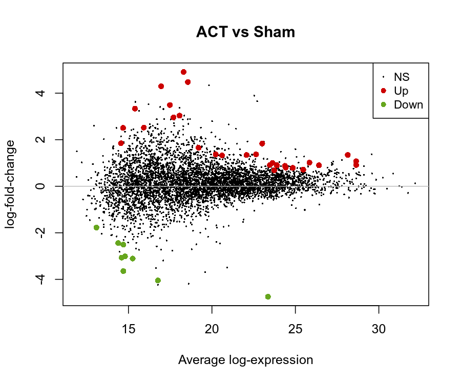

```r
## Heatmap of the differentially abundant proteins (batch-corrected, row-scaled)
top_ids <- c(tt_up$Protein, tt_down$Protein)
hm <- log_bc[top_ids, ]
rownames(hm) <- make.unique(tt$SYMBOL[match(top_ids, tt$Protein)])
save_base("heatmap_DE.pdf", width = 6, height = max(5, 0.15 * length(top_ids) + 2), {
  print(pheatmap(hm, scale = "row", cluster_cols = FALSE, silent = TRUE,
                 annotation_col = metadata[, c("group", "batch")],
                 annotation_colors = list(group = group_colors),
                 main = paste0("DE proteins (", sig_col, " < ", sig_cutoff, "), batch-corrected")))
})
```

From `ACT_mcelroy_limma_ijms730741.R`

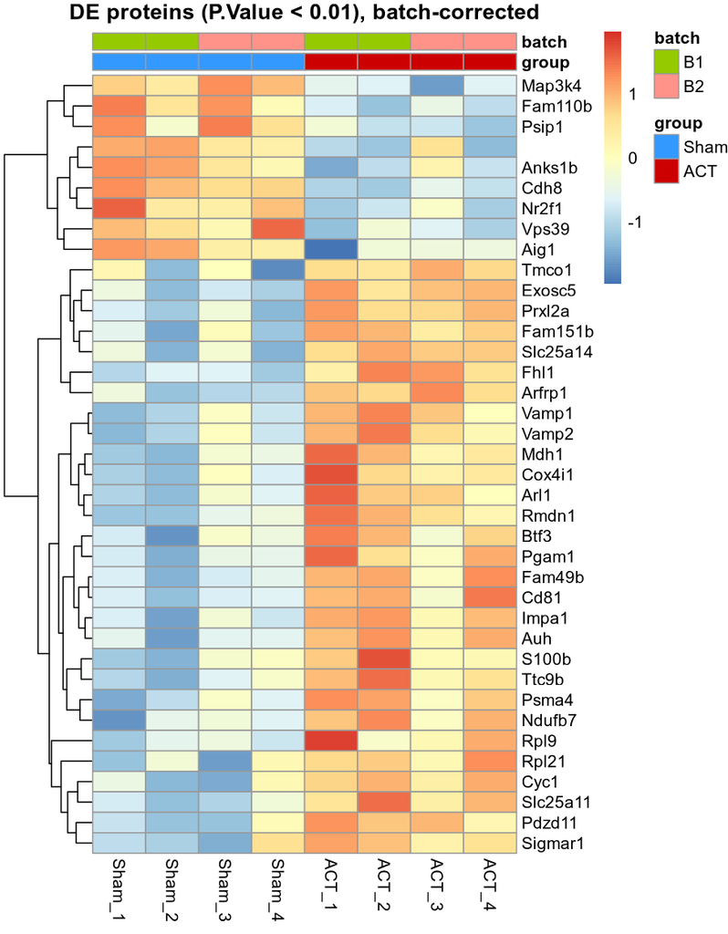

**Figure 6.** Differentially abundant proteins: imputed log2 intensities after removing the batch, scaled per row.

### P-value diagnostics

A well-behaved test has a flat p-value histogram with a peak near zero, and a QQ plot that follows the diagonal for most proteins. `plotSA` shows the intensity-dependent variance trend used by `eBayes(trend = TRUE)`.

```r
## P value / FDR histogram
save_base("pvalue_histogram.pdf", width = 8, height = 4, {
  par(mfrow = c(1, 2))
  hist(tt$P.Value, breaks = 50, col = "grey", main = "P value", xlab = "P")
  hist(tt$adj.P.Val, breaks = 50, col = "grey", main = "FDR (BH)", xlab = "adj. P")
})
```

From `ACT_mcelroy_limma_ijms730741.R`

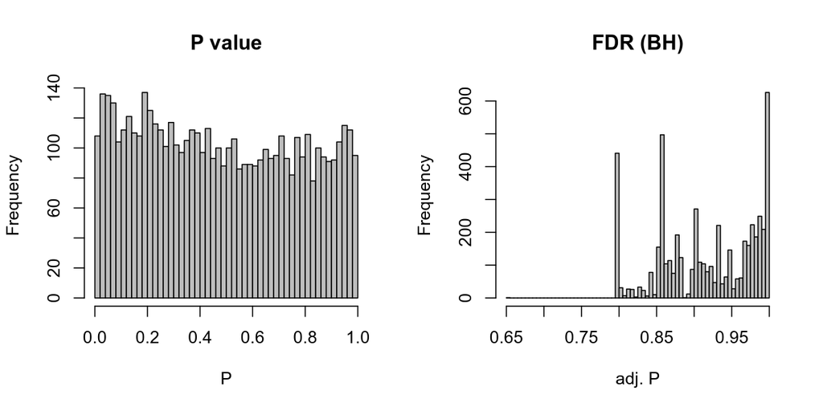

**Figure 7.** Histograms of p-values and BH-adjusted p-values.

```r
## QQ plot of moderated t
save_base("qq_t.pdf", width = 5, height = 5, {
  qqt(fit2$t[, 1], df = fit2$df.total, main = "Moderated t vs theoretical")
  abline(0, 1, col = "red")
})
```

From `ACT_mcelroy_limma_ijms730741.R`

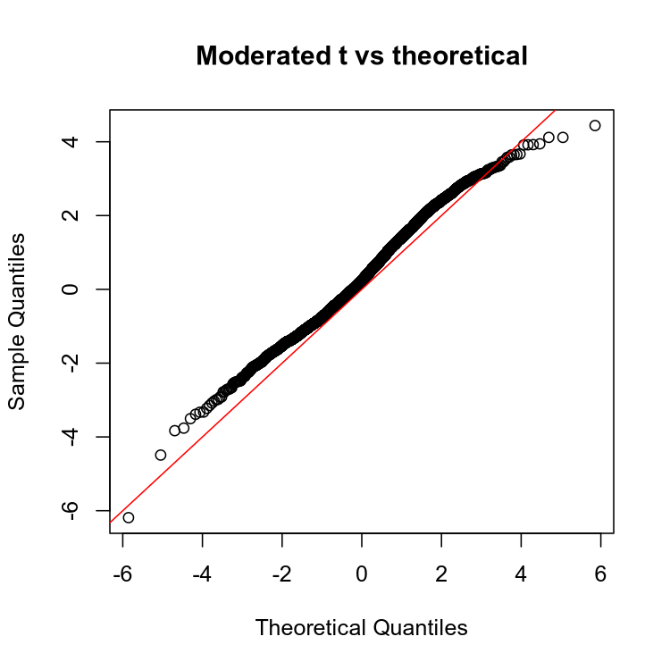

**Figure 8.** QQ plot of the moderated t statistics.

```r
## Mean-variance trend
save_base("sa_plot.pdf", width = 6, height = 5,
          plotSA(fit2, main = "Residual SD vs mean (trend = TRUE)"))
```

From `ACT_mcelroy_limma_ijms730741.R`

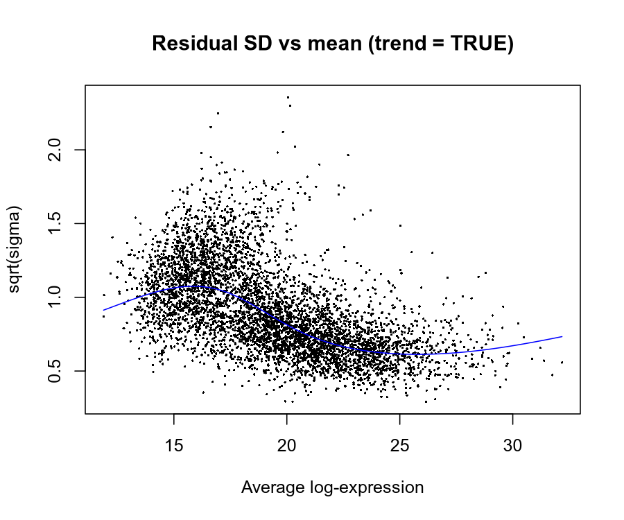

**Figure 9.** Residual standard deviation vs mean intensity, with the fitted trend.

### Differentially abundant proteins

**Table 2.** Proteins up in ACT (by P). `n_missing_*` = replicates without a value (imputed); `robust_noimp` = the call holds without imputation.

| SYMBOL | protein_name | logFC | AveExpr | P.Value | adj.P.Val | n_missing_Sham | n_missing_ACT | robust_noimp |
| --- | --- | --- | --- | --- | --- | --- | --- | --- |
| Vamp1 | Vesicle-associated membrane protein 1 (VAMP-1) (Sy | 1.84 | 23.0 | 0.00141 | 0.799 | 0 | 0 | yes |
| Exosc5 | Exosome complex component RRP46 (Exosome component | 2.51 | 14.7 | 0.00230 | 0.799 | 3 | 0 | no |
| Vamp2 | Vesicle-associated membrane protein 2 | 1.34 | 28.1 | 0.00230 | 0.799 | 0 | 0 | yes |
| Fhl1 | Four and a half LIM domains protein 1 (FHL-1) (Kyo | 1.33 | 20.6 | 0.00302 | 0.799 | 0 | 0 | yes |
| Fam151b | Family with sequence similarity 151, member B | 2.96 | 17.7 | 0.00312 | 0.799 | 1 | 0 | yes |
| Arl1 | Uncharacterized protein | 3.03 | 18.1 | 0.00314 | 0.799 | 2 | 0 | no |
| Pdzd11 | PDZ domain-containing protein 11 | 3.33 | 15.4 | 0.00317 | 0.799 | 3 | 0 | no |
| Slc25a14 | Brain mitochondrial carrier protein 1 | 2.52 | 15.9 | 0.00466 | 0.799 | 3 | 0 | no |
| Btf3 | Transcription factor BTF3 | 4.91 | 18.3 | 0.00477 | 0.799 | 1 | 0 | yes |
| Impa1 | Inositol-1-monophosphatase (EC 3.1.3.25) | 0.875 | 24.4 | 0.00482 | 0.799 | 0 | 0 | yes |
| Auh | Methylglutaconyl-CoA hydratase, mitochondrial | 0.916 | 23.5 | 0.00486 | 0.799 | 0 | 0 | yes |
| Mdh1 | Malate dehydrogenase, cytoplasmic (EC 1.1.1.37) (C | 1.07 | 28.6 | 0.00536 | 0.799 | 0 | 0 | yes |
| Cyc1 | Cytochrome c1, heme protein, mitochondrial (Comple | 1.01 | 25.8 | 0.00541 | 0.799 | 0 | 0 | yes |
| Psma4 | Proteasome subunit alpha type-4 (EC 3.4.25.1) (Mac | 1.00 | 23.6 | 0.00600 | 0.799 | 0 | 0 | yes |
| Rmdn1 | Regulator of microtubule dynamics protein 1 (RMD-1 | 1.65 | 19.2 | 0.00659 | 0.799 | 0 | 0 | yes |
| Fam49b | Protein FAM49B | 0.803 | 24.4 | 0.00659 | 0.799 | 0 | 0 | yes |
| Sigmar1 | Sigma-1 receptor short form | 4.30 | 17.0 | 0.00772 | 0.799 | 3 | 0 | no |
| Cd81 | Tetraspanin | 0.788 | 24.8 | 0.00792 | 0.799 | 0 | 0 | yes |
| Cox4i1 | Cytochrome c oxidase subunit IV isoform 1 | 0.902 | 26.4 | 0.00808 | 0.799 | 0 | 0 | yes |
| S100b | Protein S100 (S100 calcium-binding protein) | 4.48 | 18.6 | 0.00822 | 0.799 | 2 | 0 | no |
| Ttc9b | Tetratricopeptide repeat protein 9B (TPR repeat pr | 1.37 | 20.2 | 0.00829 | 0.799 | 0 | 0 | yes |
| Pgam1 | Phosphoglycerate mutase (EC 5.4.2.11) (EC 5.4.2.4) | 0.913 | 28.6 | 0.00848 | 0.799 | 0 | 0 | yes |
| Slc25a11 | Uncharacterized protein | 0.712 | 25.5 | 0.00865 | 0.799 | 0 | 0 | no |
| Rpl9 | Ribosomal protein L9 | 1.37 | 22.6 | 0.00869 | 0.799 | 0 | 0 | yes |
| Tmco1 | Calcium load-activated calcium channel (CLAC chann | 3.49 | 17.5 | 0.00907 | 0.799 | 2 | 0 | no |
| Ndufb7 | NADH dehydrogenase [ubiquinone] 1 beta subcomplex | 0.903 | 23.9 | 0.00930 | 0.799 | 0 | 0 | no |
| Rpl21 | 60S ribosomal protein L21 (Ribosomal protein L21) | 1.34 | 22.1 | 0.00937 | 0.799 | 0 | 0 | yes |
| Prxl2a | Peroxiredoxin-like 2A (Peroxiredoxin-like 2 activa | 0.688 | 23.7 | 0.00941 | 0.799 | 0 | 0 | no |
| Arfrp1 | ADP-ribosylation factor-related protein 1 (ARF-rel | 1.85 | 14.5 | 0.00981 | 0.799 | 4 | 1 | no |

**Table 3.** Proteins down in ACT (by P).

| SYMBOL | protein_name | logFC | AveExpr | P.Value | adj.P.Val | n_missing_Sham | n_missing_ACT | robust_noimp |
| --- | --- | --- | --- | --- | --- | --- | --- | --- |
| Cdh8 | Cadherin-8 | -4.05 | 16.8 | 1.26e-04 | 0.653 | 0 | 1 | yes |
| Fam110b | Protein FAM110B | -3.65 | 14.7 | 0.00130 | 0.799 | 1 | 4 | no |
| Nr2f1 | COUP transcription factor 1 (Nuclear receptor subf | -3.02 | 14.8 | 0.00361 | 0.799 | 1 | 2 | no |
|  | Protein C19orf12 homolog | -4.74 | 23.4 | 0.00403 | 0.799 | 0 | 0 | yes |
| Vps39 | CNH domain-containing protein | -2.51 | 14.7 | 0.00609 | 0.799 | 1 | 1 | no |
| Anks1b | Ankyrin repeat and sterile alpha motif domain-cont | -3.11 | 15.3 | 0.00739 | 0.799 | 0 | 3 | no |
| Map3k4 | Uncharacterized protein | -1.77 | 13.1 | 0.00810 | 0.799 | 2 | 1 | no |
| Psip1 | PC4 and SFRS1-interacting protein | -2.44 | 14.4 | 0.00816 | 0.799 | 1 | 4 | no |
| Aig1 | Uncharacterized protein | -3.07 | 14.6 | 0.00962 | 0.799 | 0 | 4 | no |

The full table is `results/ACT_vs_Sham_limma_all.csv`.

## Sensitivity to imputation

The same limma model was refit on the normalized matrix **without imputation** (limma skips missing values; proteins absent from a whole group get no estimate). The log2FC with and without imputation correlate with r = 0.655.

**20 of 38** DE calls hold without imputation (same direction, same cutoffs). Of the 18 that do not, 4 have no estimate without imputation (missing in a whole group): they are presence/absence patterns rather than quantitative changes, and their large fold changes come mostly from the imputed values.

```r
p_sens <- ggplot(tt, aes(logFC, noimp_logFC, colour = robust_noimp)) +
  geom_abline(colour = "grey") + geom_point(alpha = 0.4, size = 1) +
  geom_text_repel(data = subset(tt, status != "NS"), aes(label = SYMBOL), size = 2.5,
                  max.overlaps = 30, show.legend = FALSE) +
  scale_colour_manual(values = c(`FALSE` = "grey50", `TRUE` = "#CC0000")) +
  labs(x = "log2FC (imputed)", y = "log2FC (no imputation)", colour = "DE robust\nwithout imputation") +
  theme_bw()
save_plot(p_sens, "sensitivity_imputation_logFC.pdf", width = 8, height = 7)
```

From `ACT_mcelroy_limma_ijms730741.R`

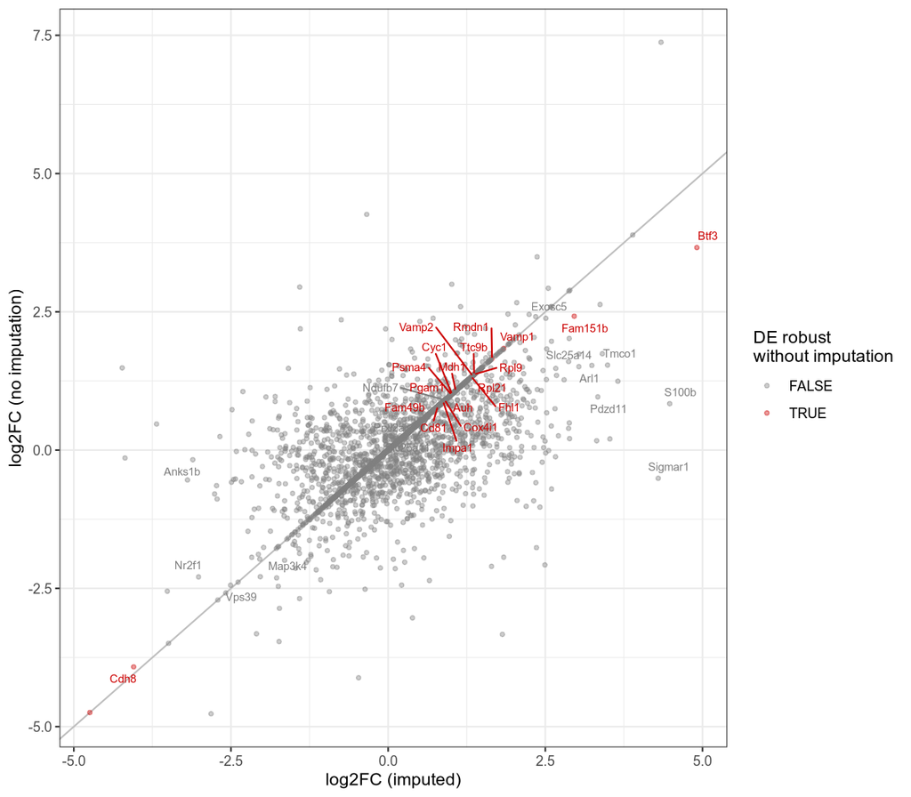

**Figure 10.** log2FC with vs without imputation. Red = DE call robust without imputation.

**Table 4.** DE calls that do not hold without imputation.

| SYMBOL | status | logFC | P.Value | noimp_logFC | noimp_P.Value | n_missing_Sham | n_missing_ACT |
| --- | --- | --- | --- | --- | --- | --- | --- |
| Fam110b | Down | -3.65 | 0.00130 |  |  | 1 | 4 |
| Exosc5 | Up | 2.51 | 0.00230 | 2.38 | 0.0610 | 3 | 0 |
| Arl1 | Up | 3.03 | 0.00314 | 1.51 | 0.131 | 2 | 0 |
| Pdzd11 | Up | 3.33 | 0.00317 | 0.963 | 0.429 | 3 | 0 |
| Nr2f1 | Down | -3.02 | 0.00361 | -2.29 | 0.128 | 1 | 2 |
| Slc25a14 | Up | 2.52 | 0.00466 | 1.83 | 0.0386 | 3 | 0 |
| Vps39 | Down | -2.51 | 0.00609 | -2.44 | 0.0194 | 1 | 1 |
| Anks1b | Down | -3.11 | 0.00739 | -0.174 | 0.867 | 0 | 3 |
| Sigmar1 | Up | 4.30 | 0.00772 | -0.509 | 0.580 | 3 | 0 |
| Map3k4 | Down | -1.77 | 0.00810 | -2.31 | 0.117 | 2 | 1 |
| Psip1 | Down | -2.44 | 0.00816 |  |  | 1 | 4 |
| S100b | Up | 4.48 | 0.00822 | 0.839 | 0.429 | 2 | 0 |
| Slc25a11 | Up | 0.712 | 0.00865 | 0.712 | 0.0112 | 0 | 0 |
| Tmco1 | Up | 3.49 | 0.00907 | 1.54 | 0.0242 | 2 | 0 |
| Ndufb7 | Up | 0.903 | 0.00930 | 0.903 | 0.0104 | 0 | 0 |
| Prxl2a | Up | 0.688 | 0.00941 | 0.688 | 0.0147 | 0 | 0 |
| Aig1 | Down | -3.07 | 0.00962 |  |  | 0 | 4 |
| Arfrp1 | Up | 1.85 | 0.00981 |  |  | 4 | 1 |

## Gene set enrichment (GSEA)

GSEA uses all tested proteins, so it also catches pathways where many proteins change a little. This is where the clearest signal of this dataset is, since few single proteins pass the cutoffs.

### GO

**104 GO terms** have `padj < 0.05` (79 enriched in ACT, 25 in Sham).

```r
save_plot(dotplot(gse_go, showCategory = 10, split = ".sign") + facet_grid(. ~ .sign),
          "gsea_GO_dotplot.pdf", width = 11, height = 8)
```

From `ACT_mcelroy_limma_ijms730741.R`

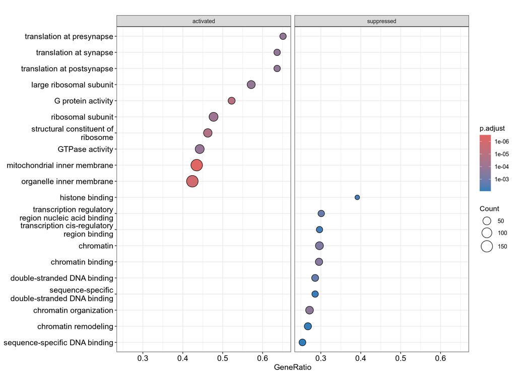

**Figure 11.** Top GO terms, split by direction (activated: NES > 0, higher in ACT; suppressed: NES < 0).

```r
save_plot(ridgeplot(gse_go, showCategory = 15) + labs(x = "signed -log10(P)"),
          "gsea_GO_ridgeplot.pdf", width = 9, height = 8)
```

From `ACT_mcelroy_limma_ijms730741.R`

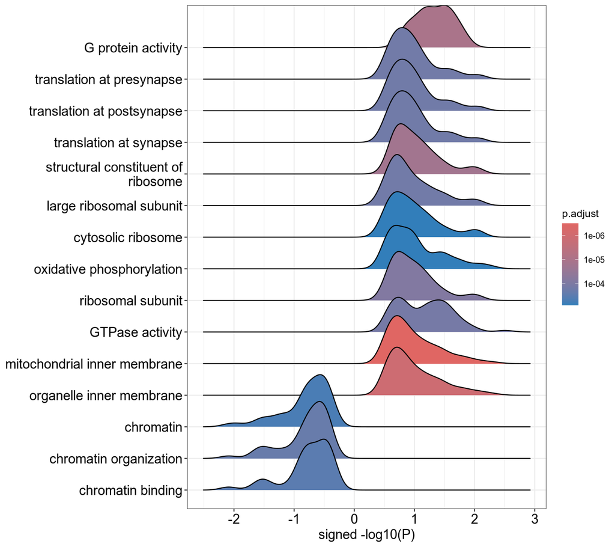

**Figure 12.** Distribution of the ranking statistic of the core proteins of each term.

```r
gse_go_sim <- pairwise_termsim(gse_go)
save_plot(emapplot(gse_go_sim, showCategory = 30), "gsea_GO_emapplot.pdf", width = 10, height = 9)
```

From `ACT_mcelroy_limma_ijms730741.R`

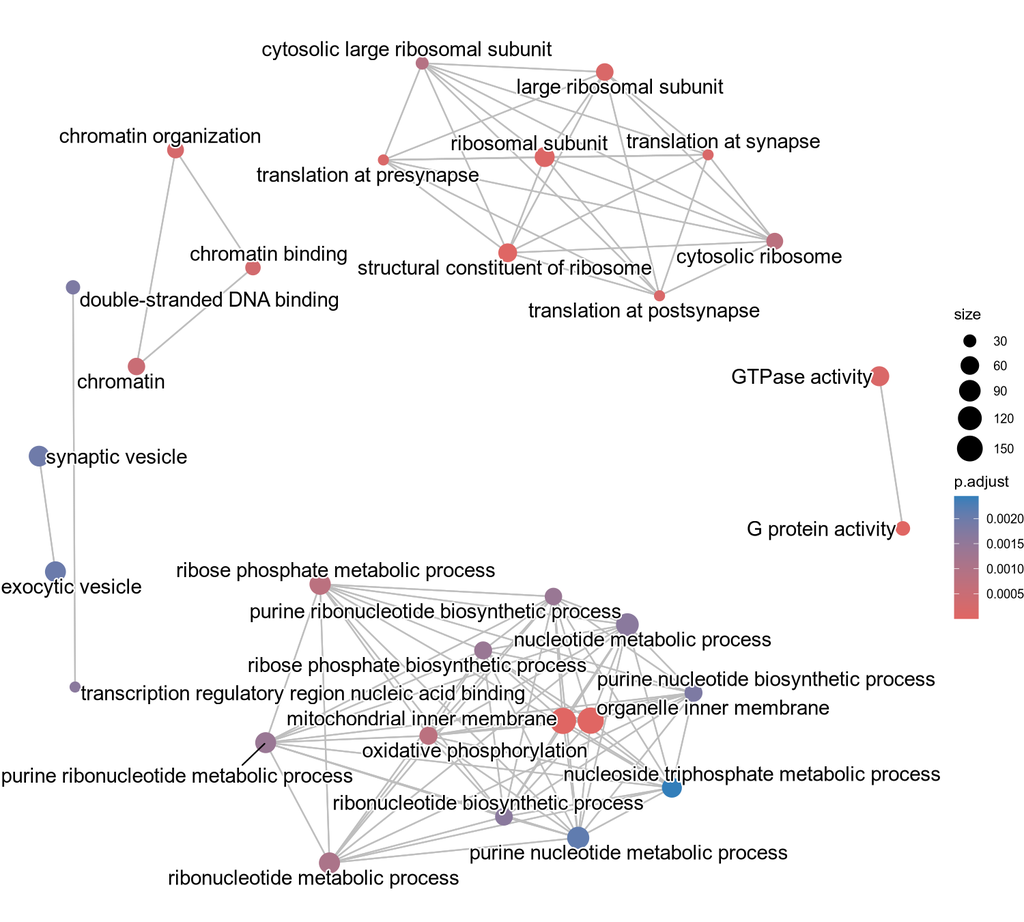

**Figure 13.** Enrichment map: terms that share proteins are linked.

```r
save_plot(gseaplot2(gse_go, geneSetID = 1, title = gse_go$Description[1], pvalue_table = TRUE),
          "gsea_GO_top1.pdf", width = 8, height = 6)
```

From `ACT_mcelroy_limma_ijms730741.R`

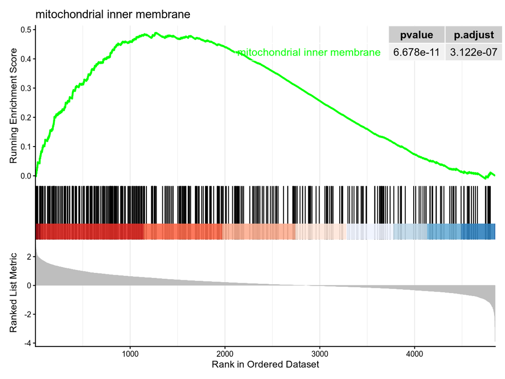

**Figure 14.** Running enrichment score of the most significant GO term.

**Table 5.** Top 10 GO terms per direction (NES > 0: enriched in ACT).

| ONTOLOGY | ID | Description | setSize | NES | p.adjust |
| --- | --- | --- | --- | --- | --- |
| CC | GO:0005743 | mitochondrial inner membrane | 361 | 1.68 | 3.12e-07 |
| CC | GO:0019866 | organelle inner membrane | 375 | 1.64 | 1.16e-06 |
| MF | GO:0003925 | G protein activity | 67 | 2.04 | 1.06e-05 |
| MF | GO:0003735 | structural constituent of ribosome | 134 | 1.88 | 1.69e-05 |
| CC | GO:0044391 | ribosomal subunit | 153 | 1.78 | 8.05e-05 |
| MF | GO:0003924 | GTPase activity | 165 | 1.76 | 1.30e-04 |
| BP | GO:0140236 | translation at presynapse | 43 | 2.01 | 1.50e-04 |
| CC | GO:0015934 | large ribosomal subunit | 91 | 1.86 | 1.50e-04 |
| BP | GO:0140241 | translation at synapse | 44 | 2.00 | 1.55e-04 |
| BP | GO:0140242 | translation at postsynapse | 44 | 2.00 | 1.55e-04 |
| BP | GO:0006325 | chromatin organization | 173 | -1.74 | 2.14e-04 |
| MF | GO:0003682 | chromatin binding | 132 | -1.80 | 3.20e-04 |
| CC | GO:0000785 | chromatin | 172 | -1.70 | 4.97e-04 |
| MF | GO:0001067 | transcription regulatory region nucleic acid binding | 93 | -1.84 | 0.00162 |
| MF | GO:0003690 | double-stranded DNA binding | 119 | -1.74 | 0.00180 |
| MF | GO:0042393 | histone binding | 46 | -2.04 | 0.00522 |
| MF | GO:0000976 | transcription cis-regulatory region binding | 91 | -1.81 | 0.00593 |
| MF | GO:1990837 | sequence-specific double-stranded DNA binding | 98 | -1.72 | 0.00767 |
| MF | GO:0043565 | sequence-specific DNA binding | 126 | -1.63 | 0.00883 |
| BP | GO:0006338 | chromatin remodeling | 142 | -1.60 | 0.00885 |

### KEGG

**12 KEGG pathways** have `padj < 0.05` (12 enriched in ACT, 0 in Sham).

```r
save_plot(dotplot(gse_kegg, showCategory = 10, split = ".sign") + facet_grid(. ~ .sign),
          "gsea_KEGG_dotplot.pdf", width = 11, height = 8)
```

From `ACT_mcelroy_limma_ijms730741.R`

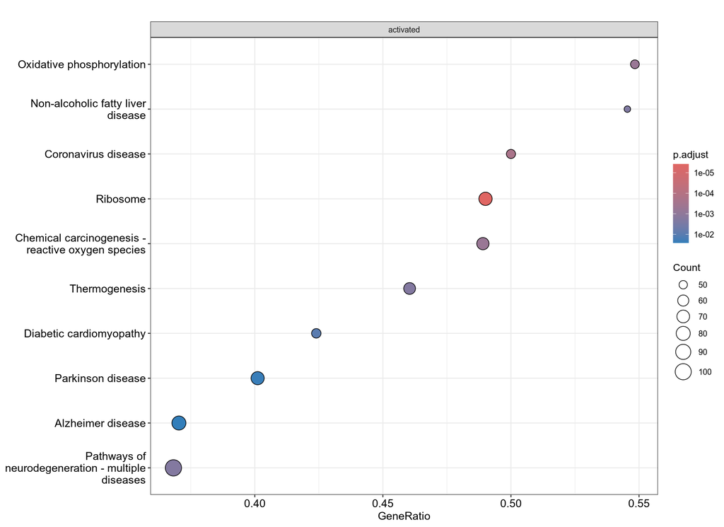

**Figure 15.** Top KEGG pathways, split by direction.

**Table 6.** Top 10 KEGG pathways per direction (NES > 0: enriched in ACT).

| ID | Description | setSize | NES | p.adjust |
| --- | --- | --- | --- | --- |
| mmu03010 | Ribosome | 151 | 1.80 | 3.80e-06 |
| mmu05171 | Coronavirus disease | 104 | 1.78 | 2.10e-04 |
| mmu00190 | Oxidative phosphorylation | 93 | 1.76 | 5.92e-04 |
| mmu05208 | Chemical carcinogenesis - reactive oxygen species | 137 | 1.67 | 5.92e-04 |
| mmu04714 | Thermogenesis | 139 | 1.61 | 0.00184 |
| mmu05022 | Pathways of neurodegeneration - multiple diseases | 277 | 1.47 | 0.00191 |
| mmu04932 | Non-alcoholic fatty liver disease | 88 | 1.70 | 0.00218 |
| mmu05415 | Diabetic cardiomyopathy | 125 | 1.56 | 0.00990 |
| mmu05012 | Parkinson disease | 182 | 1.47 | 0.0230 |
| mmu05010 | Alzheimer disease | 216 | 1.43 | 0.0259 |

## Over-representation (ORA)

No GO BP term is over-represented in the up (29) or down (9) sets at `padj < 0.05`: the sets are small compared with the ~5,200-protein background.

## Appendix

### Outputs

| File | Contents |
| --- | --- |
| `data/processed.csv` | Annotation + raw iBAQ of the Sham and ACT samples (from Table S1) |
| `results/ACT_vs_Sham_limma_all.csv` | limma results for every tested protein (with and without imputation) |
| `results/ACT_vs_Sham_limma_DE.csv` | Differentially abundant proteins |
| `results/gsea_GO.csv` | GSEA, GO (BP, CC, MF) |
| `results/gsea_KEGG.csv` | GSEA, KEGG |
| `results/run_summary.csv` | Key numbers of the run (read by this report) |

### Software

**Table 7.** Conda environments (`env/`). Snakemake builds one per rule with `--use-conda`.

| environment | packages | exact versions |
| --- | --- | --- |
| limma | r-base>=4.4, r-yaml, r-dplyr, r-tidyr, r-ggplot2, r-ggrepel, r-pheatmap, r-ggridges, r-gridextra, bioconductor-limma, bioconductor-enhancedvolcano, bioconductor-clusterprofiler, bioconductor-enrichplo… | env/limma.linux-64.pin.txt |
| prepare | python>=3.10, xlsx2csv | env/prepare.linux-64.pin.txt |
| report | python=3.12, pandas=2.3, numpy=2.3, matplotlib-base=3.10, markdown=3.9 | env/report.linux-64.pin.txt |

### Configuration

**Show config.yaml**

```yaml
# Parameters for the ACT vs Sham hippocampal proteomics analysis.
# Paths are relative to the project root (proteomics/).

dataset: ijms-730741
title: "Hippocampus proteome (McElroy et al. 2020)"

groups:
  reference: Sham
  treatment: ACT
  colors:
    Sham: "#3399FF"
    ACT: "#CC0000"

data:
  raw_xlsx: data/ijms-730741-SI.xlsx     # supplementary file (Table S1, raw iBAQ)
  processed: data/processed.csv          # output of scripts/prepare.sh, input of the R script

results_dir: results                     # CSV tables
plots_dir: plots                         # PDF + PNG figures
reports_dir: reports                     # report.html and sessionInfo.txt

seed: 42                                 # imputation and GSEA permutations

preprocessing:
  min_valid_per_group: 3                 # keep proteins quantified in >= n replicates of some group
  impute_shift: 1.8                      # MinProb: mean shift (in SD) of the imputation distribution
  impute_width: 0.3                      # MinProb: width (in SD) of the imputation distribution

de:
  fdr_cutoff: 0.05                       # BH FDR, used if any protein passes it
  nominal_cutoff: 0.01                   # unadjusted P, fallback when nothing passes FDR
  logfc_cutoff: 0.5                      # |log2FC|

enrichment:
  min_gs_size: 10
  max_gs_size: 500
  pvalue_cutoff: 0.05                    # BH-adjusted, GSEA and ORA
  run_kegg: true                         # needs internet access to rest.kegg.jp
```

### Session info

**Show R sessionInfo()**

```
R version 4.5.3 (2026-03-11)
Platform: x86_64-conda-linux-gnu
Running under: Ubuntu 26.04.1 LTS

Matrix products: default
BLAS/LAPACK: /home/arlindo/github/private/proteomics/.snakemake/conda/83093a17c497276d75c7b9aab86f783e_/lib/libopenblasp-r0.3.34.so;  LAPACK version 3.12.0

locale:
 [1] LC_CTYPE=pt_BR.UTF-8       LC_NUMERIC=C
 [3] LC_TIME=pt_BR.UTF-8        LC_COLLATE=pt_BR.UTF-8
 [5] LC_MONETARY=pt_BR.UTF-8    LC_MESSAGES=pt_BR.UTF-8
 [7] LC_PAPER=pt_BR.UTF-8       LC_NAME=C
 [9] LC_ADDRESS=C               LC_TELEPHONE=C
[11] LC_MEASUREMENT=pt_BR.UTF-8 LC_IDENTIFICATION=C

time zone: America/Sao_Paulo
tzcode source: system (glibc)

attached base packages:
[1] stats4    stats     graphics  grDevices utils     datasets  methods
[8] base

other attached packages:
 [1] yaml_2.3.12            DOSE_4.4.0             enrichplot_1.30.5
 [4] org.Mm.eg.db_3.22.0    AnnotationDbi_1.72.0   IRanges_2.44.0
 [7] S4Vectors_0.48.1       Biobase_2.70.0         BiocGenerics_0.56.0
[10] generics_0.1.4         clusterProfiler_4.18.4 EnhancedVolcano_1.28.2
[13] pheatmap_1.0.13        ggrepel_0.9.8          ggplot2_4.0.4
[16] tidyr_1.3.2            dplyr_1.2.1            limma_3.68.5

loaded via a namespace (and not attached):
 [1] DBI_1.3.0               gson_0.2.2              gridExtra_2.3.1
 [4] rlang_1.3.0             magrittr_2.0.5          otel_0.2.0
 [7] ggridges_0.5.7          compiler_4.5.3          RSQLite_3.53.3
[10] png_0.1-9               systemfonts_1.3.2       vctrs_0.7.3
[13] reshape2_1.4.5          stringr_1.6.0           pkgconfig_2.0.3
[16] crayon_1.5.3            fastmap_1.2.0           XVector_0.50.0
[19] labeling_0.4.3          purrr_1.2.2             bit_4.6.0
[22] cachem_1.1.0            aplot_0.3.2             jsonlite_2.0.0
[25] blob_1.3.0              tidydr_0.0.7            BiocParallel_1.44.0
[28] tweenr_2.0.3            cluster_2.1.8.3         parallel_4.5.3
[31] R6_2.6.1                stringi_1.8.9           RColorBrewer_1.1-3
[34] GOSemSim_2.36.0         Rcpp_1.1.2              Seqinfo_1.0.0
[37] ggtangle_0.1.4          R.utils_2.13.0          Matrix_1.7-6
[40] splines_4.5.3           igraph_2.3.4            tidyselect_1.2.1
[43] qvalue_2.42.0           codetools_0.2-20        lattice_0.23-1
[46] tibble_3.3.1            plyr_1.8.9              treeio_1.34.0
[49] withr_3.0.3             KEGGREST_1.50.0         S7_0.2.2
[52] gridGraphics_0.5-1      scatterpie_0.2.6        polyclip_1.10-7
[55] Biostrings_2.78.0       pillar_1.11.1           ggtree_4.0.5
[58] ggfun_0.2.2             scales_1.4.0            tidytree_0.4.9
[61] glue_1.8.1              gdtools_0.6.0           lazyeval_0.2.3
[64] tools_4.5.3             ggnewscale_0.5.2        data.table_1.18.6.1
[67] fgsea_1.36.2            ggiraph_0.9.6           fs_2.1.0
[70] fastmatch_1.1-8         cowplot_1.2.0           grid_4.5.3
[73] ape_5.8-1               nlme_3.1-170            patchwork_1.3.2
[76] ggforce_0.5.0           cli_3.6.6               rappdirs_0.3.4
[79] fontBitstreamVera_0.1.1 gtable_0.3.6            R.methodsS3_1.8.2
[82] yulab.utils_0.2.5       digest_0.6.39           fontquiver_0.2.1
[85] ggplotify_0.1.4         htmlwidgets_1.6.4       farver_2.1.2
[88] memoise_2.0.1           htmltools_0.5.9         R.oo_1.27.1
[91] lifecycle_1.0.5         httr_1.4.9              GO.db_3.22.0
[94] statmod_1.5.2           fontLiberation_0.1.0    bit64_4.8.6
[97] MASS_7.3-66
```